# Bellabeat-Case-Study2

Malay Raj

2023-04-20

## BELLABEAT CASE STUDY

This analysis is based on the Bellabeat case study “‘Sophisticated, Clear, and Polished’: Bellabeat data and Data Visualization”.

## PREPARE:

## Installing required packages

Installing and loading common packages and libraries.

```r
library(tidyverse)
library(skimr)
```

## COLLECTING DATA

uploading fitabase datasets(csv files) Here we’ll create a dataframes named ‘daily_activity’,‘sleep_day’,‘weight_log’ and read in the CSV files from the datasets.

```r
daily_activity <- read.csv("C:/Users/KIIT/OneDrive/Desktop/Bellabeat/Fitabase Data 4.12.16-5.12.16/updated Datasets/dailyActivity_merged.csv")
sleep_day <- read.csv("C:/Users/KIIT/OneDrive/Desktop/Bellabeat/Fitabase Data 4.12.16-5.12.16/updated Datasets/sleepDay - sleepDay_merged.csv")
weight_log <- read.csv("C:/Users/KIIT/OneDrive/Desktop/Bellabeat/Fitabase Data 4.12.16-5.12.16/updated Datasets/weightLogInfo - weightLogInfo_merged.csv")
```

## PROCESS:

## EXPLORING A FEW KEY TABLES

Take a look at all the datas.

```r
head(daily_activity)
```

```
##           Id ActivityDate TotalSteps TotalDistance TrackerDistance
## 1 1503960366    4/12/2016      13162          8.50            8.50
## 2 1503960366    4/13/2016      10735          6.97            6.97
## 3 1503960366    4/14/2016      10460          6.74            6.74
## 4 1503960366    4/15/2016       9762          6.28            6.28
## 5 1503960366    4/16/2016      12669          8.16            8.16
## 6 1503960366    4/17/2016       9705          6.48            6.48
##   LoggedActivitiesDistance VeryActiveDistance ModeratelyActiveDistance
## 1                        0               1.88                     0.55
## 2                        0               1.57                     0.69
## 3                        0               2.44                     0.40
## 4                        0               2.14                     1.26
## 5                        0               2.71                     0.41
## 6                        0               3.19                     0.78
##   LightActiveDistance SedentaryActiveDistance VeryActiveMinutes
## 1                6.06                       0                25
## 2                4.71                       0                21
## 3                3.91                       0                30
## 4                2.83                       0                29
## 5                5.04                       0                36
## 6                2.51                       0                38
##   FairlyActiveMinutes LightlyActiveMinutes SedentaryMinutes Calories
## 1                  13                  328              728     1985
## 2                  19                  217              776     1797
## 3                  11                  181             1218     1776
## 4                  34                  209              726     1745
## 5                  10                  221              773     1863
## 6                  20                  164              539     1728
```

```r
head(sleep_day)
```

```
##           Id  SleepDay TotalSleepRecords TotalMinutesAsleep TotalTimeInBed
## 1 2026352035 5/12/2016                 1                456            485
## 2 4319703577 5/12/2016                 1                302            321
## 3 4445114986 5/12/2016                 1                483            501
## 4 4702921684 5/12/2016                 1                404            442
## 5 5553957443 5/12/2016                 1                438            475
## 6 6962181067 5/12/2016                 1                516            535
```

```r
head(weight_log)
```

```
##           Id      Date WeightKg WeightPounds Fat   BMI IsManualReport
## 1 2873212765 5/12/2016     57.3     126.3249  NA 21.69           TRUE
## 2 6962181067 5/12/2016     61.9     136.4661  NA 24.17           TRUE
## 3 8877689391 5/12/2016     84.0     185.1883  NA 25.14          FALSE
## 4 6962181067 5/11/2016     61.9     136.4661  NA 24.17           TRUE
## 5 8877689391 5/11/2016     85.4     188.2748  NA 25.56          FALSE
## 6 6962181067 5/10/2016     62.1     136.9071  NA 24.24           TRUE
##          LogId
## 1 1.463098e+12
## 2 1.463098e+12
## 3 1.463035e+12
## 4 1.463011e+12
## 5 1.462950e+12
## 6 1.462925e+12
```

Identifying all the columns in the datasets.

```r
colnames(daily_activity)
```

```
##  [1] "Id"                       "ActivityDate"
##  [3] "TotalSteps"               "TotalDistance"
##  [5] "TrackerDistance"          "LoggedActivitiesDistance"
##  [7] "VeryActiveDistance"       "ModeratelyActiveDistance"
##  [9] "LightActiveDistance"      "SedentaryActiveDistance"
## [11] "VeryActiveMinutes"        "FairlyActiveMinutes"
## [13] "LightlyActiveMinutes"     "SedentaryMinutes"
## [15] "Calories"
```

```r
colnames(sleep_day)
```

```
## [1] "Id"                 "SleepDay"           "TotalSleepRecords"
## [4] "TotalMinutesAsleep" "TotalTimeInBed"
```

```r
colnames(weight_log)
```

```
## [1] "Id"             "Date"           "WeightKg"       "WeightPounds"
## [5] "Fat"            "BMI"            "IsManualReport" "LogId"
```

Note that both datasets have the ‘Id’ field - this can be used to merge the datasets.

## UNDERSTANDING SOME SUMMARY STATISTICS

How many unique participants are there in each dataframe? It looks like there may be more participants in the daily activity dataset than the sleep day dataset and weight log dataset.

```r
n_distinct(daily_activity$Id)
```

```
## [1] 33
```

```r
n_distinct(sleep_day$Id)
```

```
## [1] 24
```

```r
n_distinct(weight_log$Id)
```

```
## [1] 8
```

How many observations are there in each dataframe?

```r
nrow(daily_activity)
```

```
## [1] 940
```

```r
nrow(sleep_day)
```

```
## [1] 413
```

```r
nrow(weight_log)
```

```
## [1] 67
```

What are some quick summary statistics we’d want to know about each data frame? Let’s find out that. For the daily activity dataframe:

```r
daily_activity %>%
  select(TotalSteps,
         TotalDistance,
         SedentaryMinutes) %>%
  summary()
```

```
##    TotalSteps    TotalDistance    SedentaryMinutes
##  Min.   :    0   Min.   : 0.000   Min.   :   0.0
##  1st Qu.: 3790   1st Qu.: 2.620   1st Qu.: 729.8
##  Median : 7406   Median : 5.245   Median :1057.5
##  Mean   : 7638   Mean   : 5.490   Mean   : 991.2
##  3rd Qu.:10727   3rd Qu.: 7.713   3rd Qu.:1229.5
##  Max.   :36019   Max.   :28.030   Max.   :1440.0
```

For the sleep day dataframe:

```r
sleep_day %>%
  select(TotalSleepRecords,
         TotalMinutesAsleep,
         TotalTimeInBed) %>%
  summary()
```

```
##  TotalSleepRecords TotalMinutesAsleep TotalTimeInBed
##  Min.   :1.000     Min.   : 58.0      Min.   : 61.0
##  1st Qu.:1.000     1st Qu.:361.0      1st Qu.:403.0
##  Median :1.000     Median :433.0      Median :463.0
##  Mean   :1.119     Mean   :419.5      Mean   :458.6
##  3rd Qu.:1.000     3rd Qu.:490.0      3rd Qu.:526.0
##  Max.   :3.000     Max.   :796.0      Max.   :961.0
```

For the weight log dataframe:

```r
weight_log %>%
  select(WeightKg,
         WeightPounds,
         BMI) %>%
  summary()
```

```
##     WeightKg       WeightPounds        BMI
##  Min.   : 52.60   Min.   :116.0   Min.   :21.45
##  1st Qu.: 61.40   1st Qu.:135.4   1st Qu.:23.96
##  Median : 62.50   Median :137.8   Median :24.39
##  Mean   : 72.04   Mean   :158.8   Mean   :25.19
##  3rd Qu.: 85.05   3rd Qu.:187.5   3rd Qu.:25.56
##  Max.   :133.50   Max.   :294.3   Max.   :47.54
```

## ANALYZE:

We then run a quick summary on the various data frames by using the skim_without_chart() function to provide broader overview of a data frames.

```r
skim_without_charts(daily_activity)
```

Data summary

| Name | daily_activity |
| --- | --- |
| Number of rows | 940 |
| Number of columns | 15 |
| _______________________ |  |
| Column type frequency: |  |
| character | 1 |
| numeric | 14 |
| ________________________ |  |
| Group variables | None |

**Variable type: character**

| skim_variable | n_missing | complete_rate | min | max | empty | n_unique | whitespace |
| --- | --- | --- | --- | --- | --- | --- | --- |
| ActivityDate | 0 | 1 | 8 | 9 | 0 | 31 | 0 |

**Variable type: numeric**

| skim_variable | n_missing | complete_rate | mean | sd | p0 | p25 | p50 | p75 | p100 |
| --- | --- | --- | --- | --- | --- | --- | --- | --- | --- |
| Id | 0 | 1 | 4.855407e+09 | 2.424805e+09 | 1503960366 | 2.320127e+09 | 4.445115e+09 | 6.962181e+09 | 8.877689e+09 |
| TotalSteps | 0 | 1 | 7.637910e+03 | 5.087150e+03 | 0 | 3.789750e+03 | 7.405500e+03 | 1.072700e+04 | 3.601900e+04 |
| TotalDistance | 0 | 1 | 5.490000e+00 | 3.920000e+00 | 0 | 2.620000e+00 | 5.240000e+00 | 7.710000e+00 | 2.803000e+01 |
| TrackerDistance | 0 | 1 | 5.480000e+00 | 3.910000e+00 | 0 | 2.620000e+00 | 5.240000e+00 | 7.710000e+00 | 2.803000e+01 |
| LoggedActivitiesDistance | 0 | 1 | 1.100000e-01 | 6.200000e-01 | 0 | 0.000000e+00 | 0.000000e+00 | 0.000000e+00 | 4.940000e+00 |
| VeryActiveDistance | 0 | 1 | 1.500000e+00 | 2.660000e+00 | 0 | 0.000000e+00 | 2.100000e-01 | 2.050000e+00 | 2.192000e+01 |
| ModeratelyActiveDistance | 0 | 1 | 5.700000e-01 | 8.800000e-01 | 0 | 0.000000e+00 | 2.400000e-01 | 8.000000e-01 | 6.480000e+00 |
| LightActiveDistance | 0 | 1 | 3.340000e+00 | 2.040000e+00 | 0 | 1.950000e+00 | 3.360000e+00 | 4.780000e+00 | 1.071000e+01 |
| SedentaryActiveDistance | 0 | 1 | 0.000000e+00 | 1.000000e-02 | 0 | 0.000000e+00 | 0.000000e+00 | 0.000000e+00 | 1.100000e-01 |
| VeryActiveMinutes | 0 | 1 | 2.116000e+01 | 3.284000e+01 | 0 | 0.000000e+00 | 4.000000e+00 | 3.200000e+01 | 2.100000e+02 |
| FairlyActiveMinutes | 0 | 1 | 1.356000e+01 | 1.999000e+01 | 0 | 0.000000e+00 | 6.000000e+00 | 1.900000e+01 | 1.430000e+02 |
| LightlyActiveMinutes | 0 | 1 | 1.928100e+02 | 1.091700e+02 | 0 | 1.270000e+02 | 1.990000e+02 | 2.640000e+02 | 5.180000e+02 |
| SedentaryMinutes | 0 | 1 | 9.912100e+02 | 3.012700e+02 | 0 | 7.297500e+02 | 1.057500e+03 | 1.229500e+03 | 1.440000e+03 |
| Calories | 0 | 1 | 2.303610e+03 | 7.181700e+02 | 0 | 1.828500e+03 | 2.134000e+03 | 2.793250e+03 | 4.900000e+03 |

```r
skim_without_charts(sleep_day)
```

Data summary

| Name | sleep_day |
| --- | --- |
| Number of rows | 413 |
| Number of columns | 5 |
| _______________________ |  |
| Column type frequency: |  |
| character | 1 |
| numeric | 4 |
| ________________________ |  |
| Group variables | None |

**Variable type: character**

| skim_variable | n_missing | complete_rate | min | max | empty | n_unique | whitespace |
| --- | --- | --- | --- | --- | --- | --- | --- |
| SleepDay | 0 | 1 | 8 | 9 | 0 | 31 | 0 |

**Variable type: numeric**

| skim_variable | n_missing | complete_rate | mean | sd | p0 | p25 | p50 | p75 | p100 |
| --- | --- | --- | --- | --- | --- | --- | --- | --- | --- |
| Id | 0 | 1 | 5.000979e+09 | 2.06036e+09 | 1503960366 | 3977333714 | 4702921684 | 6962181067 | 8792009665 |
| TotalSleepRecords | 0 | 1 | 1.120000e+00 | 3.50000e-01 | 1 | 1 | 1 | 1 | 3 |
| TotalMinutesAsleep | 0 | 1 | 4.194700e+02 | 1.18340e+02 | 58 | 361 | 433 | 490 | 796 |
| TotalTimeInBed | 0 | 1 | 4.586400e+02 | 1.27100e+02 | 61 | 403 | 463 | 526 | 961 |

```r
skim_without_charts(weight_log)
```

Data summary

| Name | weight_log |
| --- | --- |
| Number of rows | 67 |
| Number of columns | 8 |
| _______________________ |  |
| Column type frequency: |  |
| character | 1 |
| logical | 1 |
| numeric | 6 |
| ________________________ |  |
| Group variables | None |

**Variable type: character**

| skim_variable | n_missing | complete_rate | min | max | empty | n_unique | whitespace |
| --- | --- | --- | --- | --- | --- | --- | --- |
| Date | 0 | 1 | 8 | 9 | 0 | 31 | 0 |

**Variable type: logical**

| skim_variable | n_missing | complete_rate | mean | count |
| --- | --- | --- | --- | --- |
| IsManualReport | 0 | 1 | 0.61 | TRU: 41, FAL: 26 |

**Variable type: numeric**

| skim_variable | n_missing | complete_rate | mean | sd | p0 | p25 | p50 | p75 | p100 |
| --- | --- | --- | --- | --- | --- | --- | --- | --- | --- |
| Id | 0 | 1.00 | 7.009282e+09 | 1.950322e+09 | 1.503960e+09 | 6.962181e+09 | 6.962181e+09 | 8.877689e+09 | 8.877689e+09 |
| WeightKg | 0 | 1.00 | 7.204000e+01 | 1.392000e+01 | 5.260000e+01 | 6.140000e+01 | 6.250000e+01 | 8.505000e+01 | 1.335000e+02 |
| WeightPounds | 0 | 1.00 | 1.588100e+02 | 3.070000e+01 | 1.159600e+02 | 1.353600e+02 | 1.377900e+02 | 1.875000e+02 | 2.943200e+02 |
| Fat | 65 | 0.03 | 2.350000e+01 | 2.120000e+00 | 2.200000e+01 | 2.275000e+01 | 2.350000e+01 | 2.425000e+01 | 2.500000e+01 |
| BMI | 0 | 1.00 | 2.519000e+01 | 3.070000e+00 | 2.145000e+01 | 2.396000e+01 | 2.439000e+01 | 2.556000e+01 | 4.754000e+01 |
| LogId | 0 | 1.00 | 1.461772e+12 | 7.829948e+08 | 1.460444e+12 | 1.461079e+12 | 1.461802e+12 | 1.462375e+12 | 1.463098e+12 |

## Exploring Avg sleep time $ Avg time in bed

```r
Avg_minutes_asleep <- sleep_day %>% summarize(avg_sleeptime = mean(TotalMinutesAsleep))
```

```r
Avg_minutes_asleep
```

```
##   avg_sleeptime
## 1      419.4673
```

```r
Avg_TimeInBed <- sleep_day %>%
summarize(avg_TimeInBed = mean(TotalTimeInBed))
```

```r
Avg_TimeInBed
```

```
##   avg_TimeInBed
## 1      458.6392
```

Above exploration showes the average participants stayed up 40 minutes in bed before they fell asleep.

```r
daily_activity <- daily_activity %>%
  mutate(weekday1 = weekdays(as.Date(ActivityDate, "%m/%d/%Y")))

glimpse(daily_activity)
```

```
## Rows: 940
## Columns: 16
## $ Id                       <dbl> 1503960366, 1503960366, 1503960366, 150396036…
## $ ActivityDate             <chr> "4/12/2016", "4/13/2016", "4/14/2016", "4/15/…
## $ TotalSteps               <int> 13162, 10735, 10460, 9762, 12669, 9705, 13019…
## $ TotalDistance            <dbl> 8.50, 6.97, 6.74, 6.28, 8.16, 6.48, 8.59, 9.8…
## $ TrackerDistance          <dbl> 8.50, 6.97, 6.74, 6.28, 8.16, 6.48, 8.59, 9.8…
## $ LoggedActivitiesDistance <dbl> 0, 0, 0, 0, 0, 0, 0, 0, 0, 0, 0, 0, 0, 0, 0, …
## $ VeryActiveDistance       <dbl> 1.88, 1.57, 2.44, 2.14, 2.71, 3.19, 3.25, 3.5…
## $ ModeratelyActiveDistance <dbl> 0.55, 0.69, 0.40, 1.26, 0.41, 0.78, 0.64, 1.3…
## $ LightActiveDistance      <dbl> 6.06, 4.71, 3.91, 2.83, 5.04, 2.51, 4.71, 5.0…
## $ SedentaryActiveDistance  <dbl> 0, 0, 0, 0, 0, 0, 0, 0, 0, 0, 0, 0, 0, 0, 0, …
## $ VeryActiveMinutes        <int> 25, 21, 30, 29, 36, 38, 42, 50, 28, 19, 66, 4…
## $ FairlyActiveMinutes      <int> 13, 19, 11, 34, 10, 20, 16, 31, 12, 8, 27, 21…
## $ LightlyActiveMinutes     <int> 328, 217, 181, 209, 221, 164, 233, 264, 205, …
## $ SedentaryMinutes         <int> 728, 776, 1218, 726, 773, 539, 1149, 775, 818…
## $ Calories                 <int> 1985, 1797, 1776, 1745, 1863, 1728, 1921, 203…
## $ weekday1                 <chr> "Tuesday", "Wednesday", "Thursday", "Friday",…
```

```r
daily_activity$weekday1 <- ordered(daily_activity$weekday1, levels=c("Monday","Tuesday","Wednesday","Thursday","Friday","Saturday","Sunday"))
```

```r
activity_data <- daily_activity %>%
  group_by(weekday1) %>%
  summarize(count_of = n())

glimpse(activity_data)
```

```
## Rows: 7
## Columns: 2
## $ weekday1 <ord> Monday, Tuesday, Wednesday, Thursday, Friday, Saturday, Sunday
## $ count_of <int> 120, 152, 150, 147, 126, 124, 121
```

## VISUALIZATION

Let’s see the number of times the users track their activities in a week.

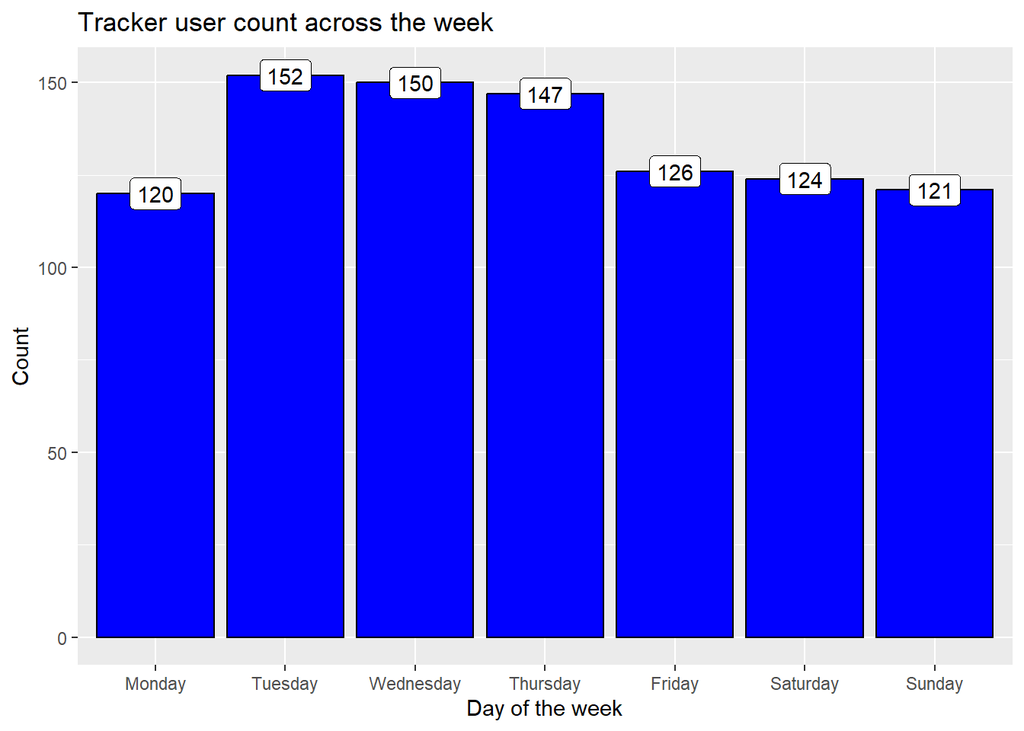

```r
ggplot(activity_data, aes(x=weekday1, y=count_of)) +
  geom_bar(stat="identity",color="black",fill="#0000FF") +
  labs(title="Tracker user count across the week", x="Day of the week", y="Count") +
  geom_label(aes(label=count_of),color="black")
```

The results shows that most of the activities recorded were on Tuesday, Wednesday and Thursday.

## Plotting a few other explorations.

Let’s find out what’s the relationship between steps taken in a day and sedentary minutes.

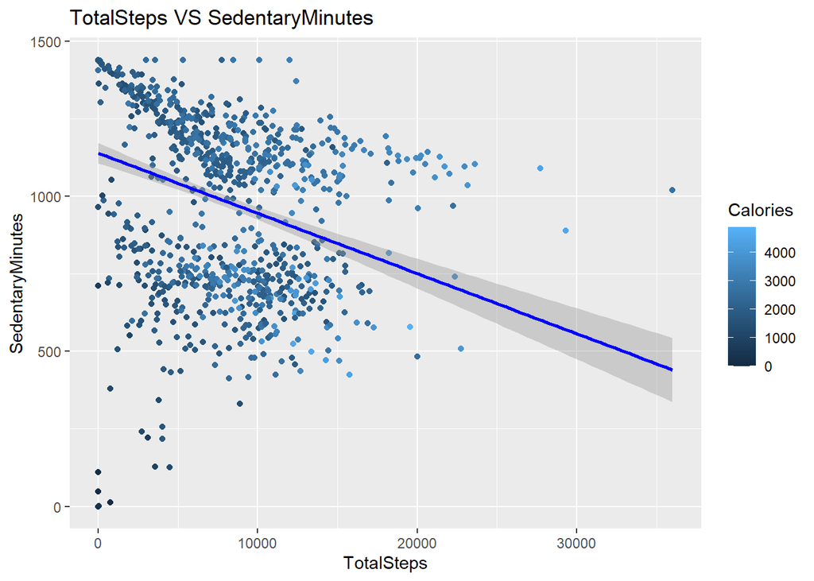

```r
ggplot(data=daily_activity, aes(x=TotalSteps, y=SedentaryMinutes, color=Calories)) + geom_point() + ggtitle("TotalSteps VS SedentaryMinutes") + geom_smooth(method="lm",color="blue")
```

Observing relationship between steps taken and calories burned.

```r
mean_steps <- mean(daily_activity$TotalSteps)
mean_steps
```

```
## [1] 7637.911
```

```r
mean_calories <- mean(daily_activity$Calories)
mean_calories
```

```
## [1] 2303.61
```

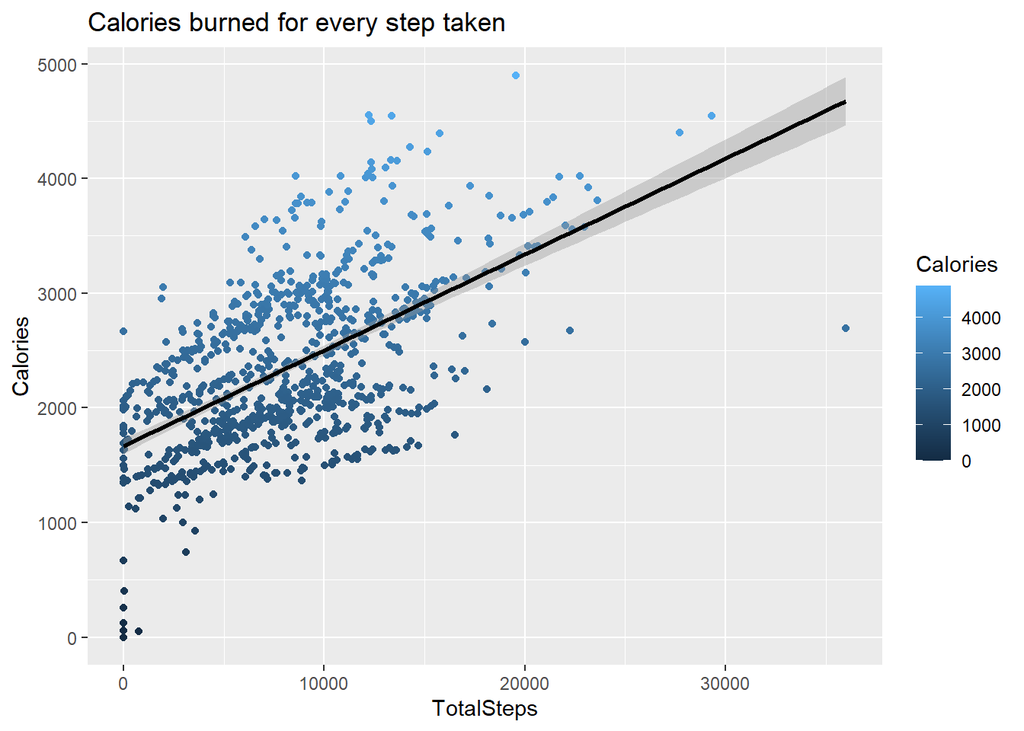

```r
ggplot(data=daily_activity, aes(x=TotalSteps, y=Calories, color=Calories)) + geom_point() + ggtitle("Calories burned for every step taken") + geom_smooth(method="lm", color="black")
```

The visualization above shows a positive correlation between the steps taken and the calories burnt.

Let’s find out what’s the relationship between minutes asleep and time in bed.

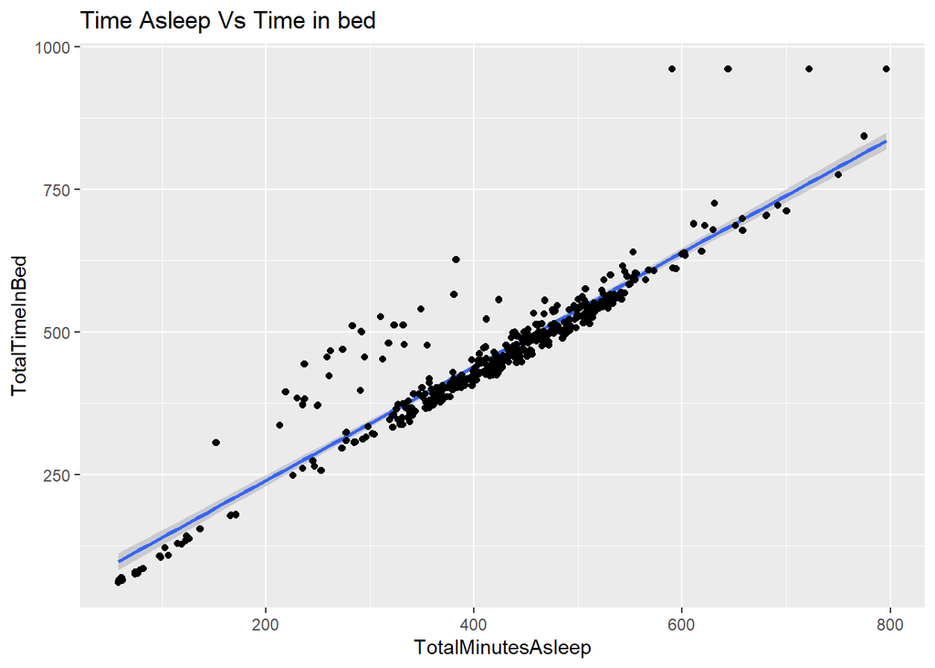

```r
ggplot(data=sleep_day, aes(x=TotalMinutesAsleep, y=TotalTimeInBed)) + geom_point() + ggtitle("Time Asleep Vs Time in bed") + geom_smooth(method="lm") + geom_jitter()
```

Relationship between being sedentary, light, fairly light, very active minutes and calories burned.

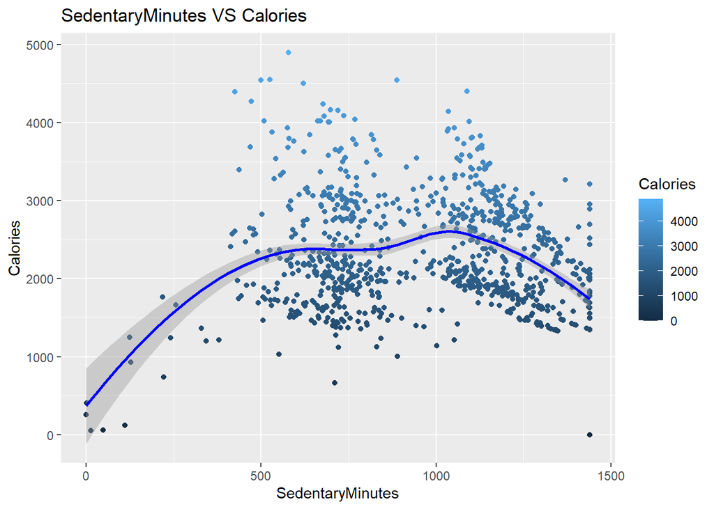

```r
ggplot(data=daily_activity, aes(x=SedentaryMinutes, y=Calories, color=Calories)) + geom_point() + ggtitle("SedentaryMinutes VS Calories") + geom_smooth(method="loess",color="blue")
```

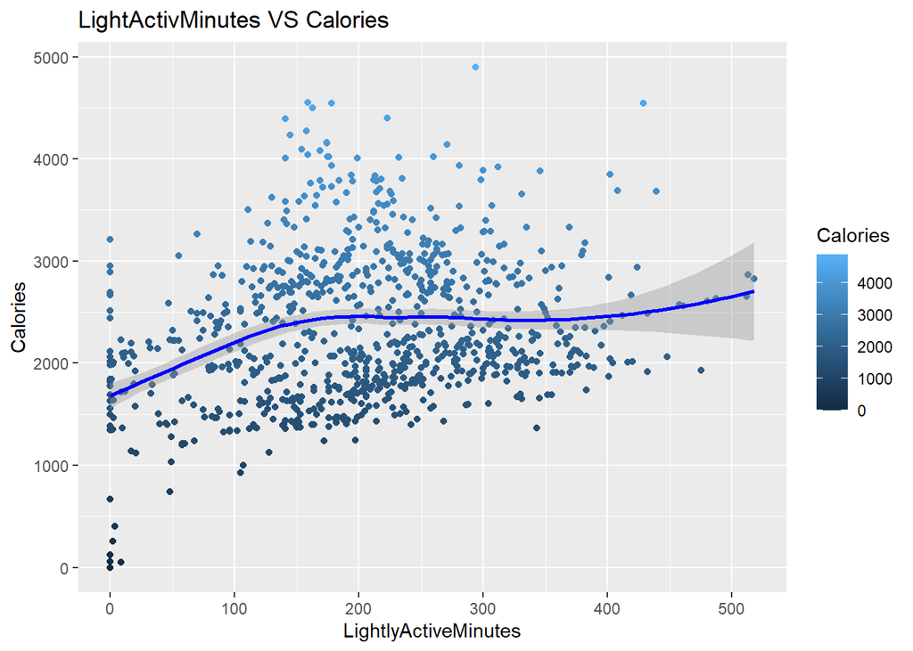

```r
ggplot(data=daily_activity, aes(x=LightlyActiveMinutes, y=Calories, color=Calories)) + geom_point() + ggtitle("LightActivMinutes VS Calories") + geom_smooth(method="loess",color="blue")
```

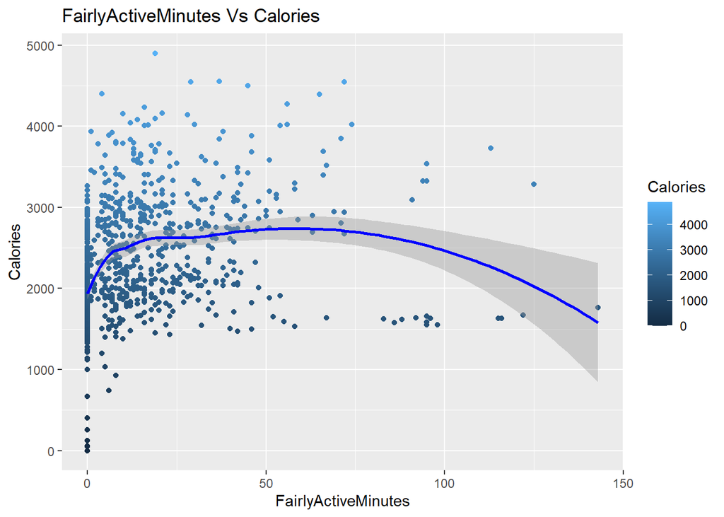

```r
ggplot(data=daily_activity, aes(x=FairlyActiveMinutes, y=Calories, color=Calories)) + geom_point() + ggtitle("FairlyActiveMinutes Vs Calories") + geom_smooth(method="loess",color="blue")
```

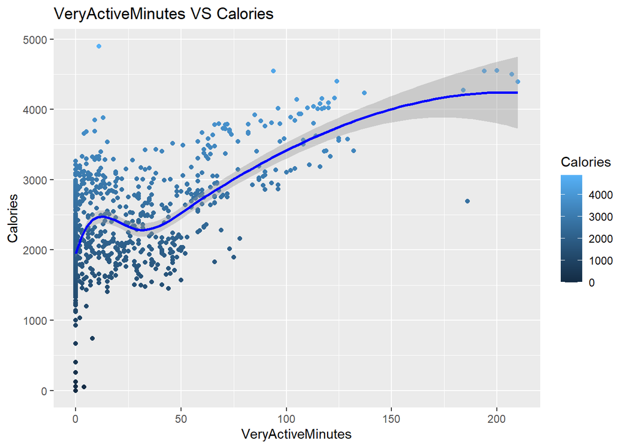

```r
ggplot(data=daily_activity, aes(x=VeryActiveMinutes, y=Calories, color=Calories)) + geom_point() + ggtitle("VeryActiveMinutes VS Calories") + geom_smooth(method="loess",color="blue")
```

Above vizualization is showing positive correlation between very active minutes and calories burned.